# Topic_model_answerkey

### Section 1: Introduction of Topic Modeling

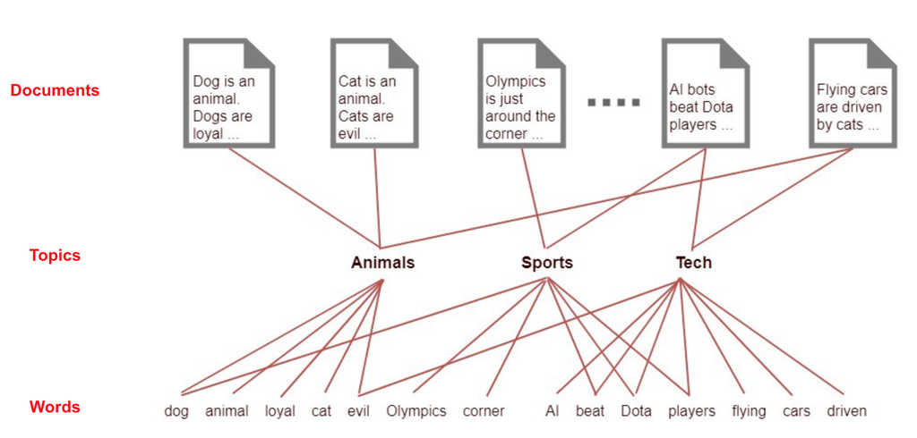

```r
knitr::include_graphics("https://aiml.com/wp-content/uploads/2023/09/example-of-topic-modeling.png")
```

Topic modeling is a method for unsupervised classification. Latent Dirichlet allocation (LDA) is a particularly popular method for fitting a topic model. This allows documents to “overlap” each other in terms of content, rather than being separated into discrete groups, in a way that mirrors typical use of natural language.

- use package `topicmodels` in `library()`
- call `data("AssociatedPress")` and also check data `AssociatedPress`

```r
library(topicmodels)

data("AssociatedPress")
AssociatedPress
```

```
## <<DocumentTermMatrix (documents: 2246, terms: 10473)>>
## Non-/sparse entries: 302031/23220327
## Sparsity           : 99%
## Maximal term length: 18
## Weighting          : term frequency (tf)
```

We can use the `LDA()` function from the topicmodels package, setting `k = 2`, to create a two-topic LDA model.

```r
# set a seed so that the output of the model is predictable
ap_lda <- LDA(AssociatedPress, k = 2, control = list(seed = 1234))
ap_lda
```

```
## A LDA_VEM topic model with 2 topics.
```

### Section 2: Word-topic probabilities

The tidytext package provides this method for extracting the per-topic-per-word probabilities, called β (“beta”), from the model.

```r
library(tidytext)
ap_topics <- tidy(ap_lda, matrix = "beta")
```

```r
library(tidytext)
ap_topics <- tidy(ap_lda, matrix = "beta")
ap_topics
```

```
## # A tibble: 20,946 × 3
##    topic term           beta
##    <int> <chr>         <dbl>
##  1     1 aaron      1.69e-12
##  2     2 aaron      3.90e- 5
##  3     1 abandon    2.65e- 5
##  4     2 abandon    3.99e- 5
##  5     1 abandoned  1.39e- 4
##  6     2 abandoned  5.88e- 5
##  7     1 abandoning 2.45e-33
##  8     2 abandoning 2.34e- 5
##  9     1 abbott     2.13e- 6
## 10     2 abbott     2.97e- 5
## # ℹ 20,936 more rows
```

use dplyr’s slice_max() to find the 10 terms that are most common within each topic. As a tidy data frame, this lends itself well to a ggplot2 visualization

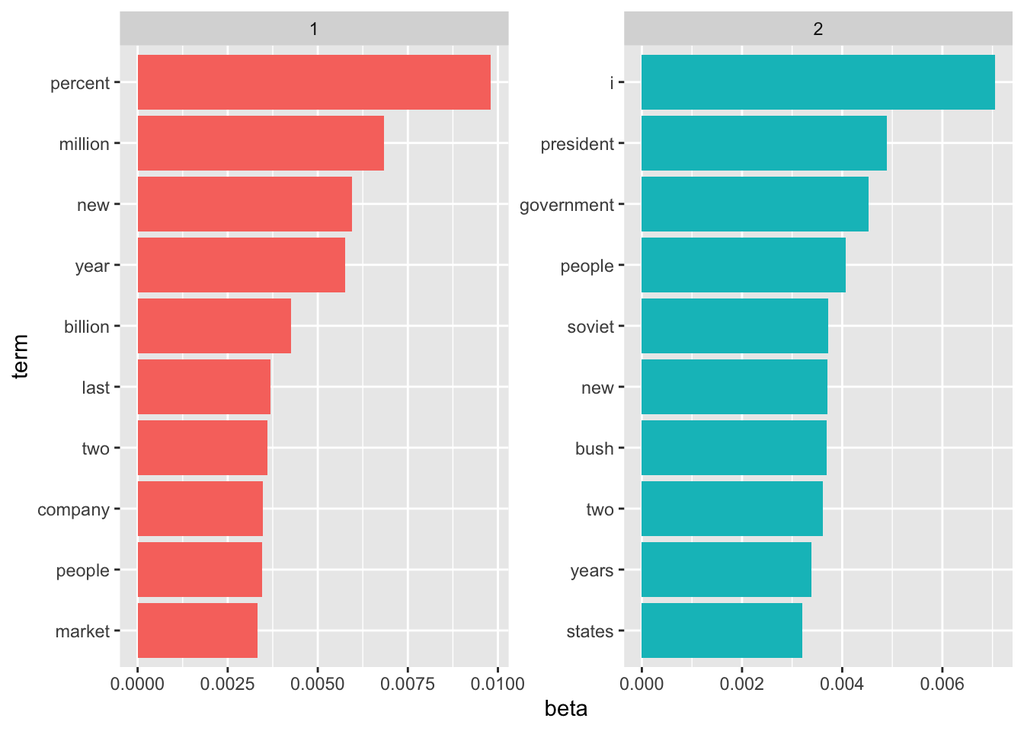

```r
library(ggplot2)
library(dplyr)
ap_top_terms <- ap_topics %>%
  group_by(topic) %>%
  slice_max(beta, n = 10) %>%
  ungroup() %>%
  arrange(topic, -beta)

ap_top_terms %>%
  mutate(term = reorder_within(term, beta, topic)) %>%
  ggplot(aes(beta, term, fill = factor(topic))) +
  geom_col(show.legend = FALSE) +
  facet_wrap(~ topic, scales = "free") +
  scale_y_reordered()
```

## explanation

```r
library(tidyr)

beta_wide <- ap_topics %>%
  mutate(topic = paste0("topic", topic)) %>%
  pivot_wider(names_from = topic, values_from = beta) %>%
  filter(topic1 > .001 | topic2 > .001) %>%
  mutate(log_ratio = log2(topic2 / topic1))

beta_wide
```

```
## # A tibble: 198 × 4
##    term              topic1      topic2 log_ratio
##    <chr>              <dbl>       <dbl>     <dbl>
##  1 administration 0.000431  0.00138         1.68
##  2 ago            0.00107   0.000842       -0.339
##  3 agreement      0.000671  0.00104         0.630
##  4 aid            0.0000476 0.00105         4.46
##  5 air            0.00214   0.000297       -2.85
##  6 american       0.00203   0.00168        -0.270
##  7 analysts       0.00109   0.000000578   -10.9
##  8 area           0.00137   0.000231       -2.57
##  9 army           0.000262  0.00105         2.00
## 10 asked          0.000189  0.00156         3.05
## # ℹ 188 more rows
```

### Section 3: Document-topic probabilities

Besides estimating each topic as a mixture of words, LDA also models each document as a mixture of topics. We can examine the per-document-per-topic probabilities, called γ (“gamma”), with the matrix = “gamma” argument to tidy().

```r
ap_documents <- tidy(ap_lda, matrix = "gamma")
ap_documents
```

```
## # A tibble: 4,492 × 3
##    document topic    gamma
##       <int> <int>    <dbl>
##  1        1     1 0.248
##  2        2     1 0.362
##  3        3     1 0.527
##  4        4     1 0.357
##  5        5     1 0.181
##  6        6     1 0.000588
##  7        7     1 0.773
##  8        8     1 0.00445
##  9        9     1 0.967
## 10       10     1 0.147
## # ℹ 4,482 more rows
```

We can see that many of these documents were drawn from a mix of the two topics, but that document 6 was drawn almost entirely from topic 2, having a γfrom topic 1 close to zero. To check this answer, we could tidy() the document-term matrix and check what the most common words in that document were.

```r
tidy(AssociatedPress) %>%
  filter(document == 6) %>%
  arrange(desc(count))
```

```
## # A tibble: 287 × 3
##    document term           count
##       <int> <chr>          <dbl>
##  1        6 noriega           16
##  2        6 panama            12
##  3        6 jackson            6
##  4        6 powell             6
##  5        6 administration     5
##  6        6 economic           5
##  7        6 general            5
##  8        6 i                  5
##  9        6 panamanian         5
## 10        6 american           4
## # ℹ 277 more rows
```

### Section 4: How to find K with `FindTopicsNumber()`

The previous steps have already shown the output when topic number is 2 (k=2). When doing LDA in practice, determining K is key. If the topic number (k) is too small, the categorization of the dataset could be very general. However, if the topic number (K) is too large, topics may overlap and become hard to interpret.

In real analysis, we can re-run the unsupervised model multiple times, manually adjusting the number of topics (k) that LDA looks for, for example, k = 2, k = 3, and so on. We should then manually inspect the terms associated with the topics to check their thematic consistency. We should evaluate whether the topics and associated terms are coherent, consistent, and accurately reflect the themes present in the data. Through this evaluation process, we can determine the optimal number of topics (k = ?). We can also manually identify the topics and associated terms to develop a dictionary and conduct semi-supervised, seeded topic modeling https://ladal.edu.au/tutorials/topic/topic.html#human-in-the-loop-topic-modelling)

Here we focus on `FindTopicsNumber()` to determine the optimal topic number K.

first, we install `ldatuning` from Github

```r
# Load remotes package
library(remotes)

# Install ldatuning from GitHub
install_github("nikita-moor/ldatuning")
```

```
## Skipping install of 'ldatuning' from a github remote, the SHA1 (661fabb4) has not changed since last install.
##   Use `force = TRUE` to force installation
```

Second, we use `FindTopicsNumber()` function to create models with different numbers of topics (from k =2 to k = 20).

Note that the `FindTopicsNumber()` function has four metrics: Griffiths2004, CaoJuan2009, Arun2010, and Deveaud2014. Here we focus on Caojuan2009 https://doi.org/10.1016/j.neucom.2008.06.011and Deveaud2014 https://hal.science/hal-01002716v1. CaoJuan2009 can be simply understood as minimizing similarities between topics, so you need to identify the minimum point to determine the optimal K. Deveaud2014 measures the divergence between topics, which suggests that we should identify the maximum point.

```r
# Load ldatuning package
library(ldatuning)

# Use FindTopicsNumber() to fit models with topic numbers from 2 to 20
result <- ldatuning::FindTopicsNumber(
  AssociatedPress,
  topics = seq(from = 2, to = 20, by = 1),
  metrics = c("CaoJuan2009",  "Deveaud2014"),
  method = "Gibbs",  # Gibbs sampling is an estimation method, usually taking longer time?
  control = list(seed = 77),
  verbose = TRUE # Show progress method
)
```

```
## fit models... done.
## calculate metrics:
##   CaoJuan2009... done.
##   Deveaud2014... done.
```

Now, we can plot the results using `FindTopicsNumber_plot()`.

To identify the optimal K, several methods should converge. For example, here, we should look for the peak value for Deveaud2014 and the dip value for CaoJuan2009.

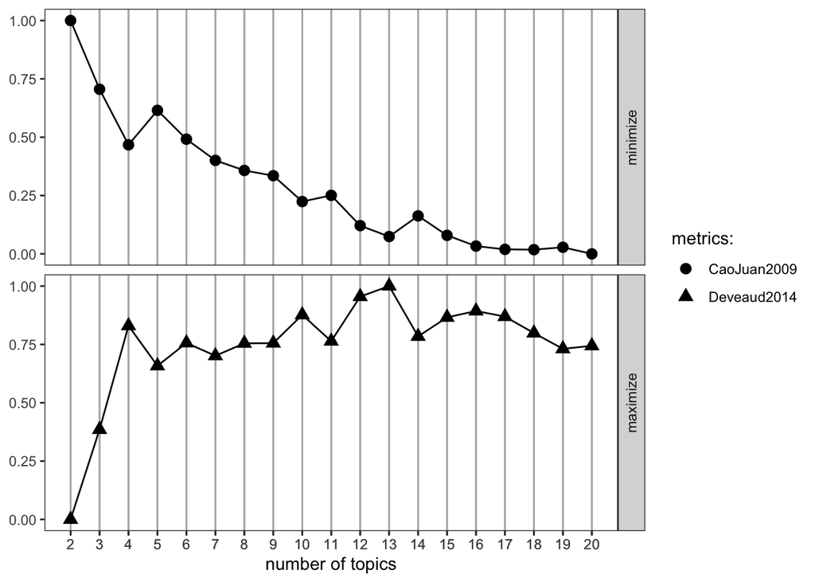

```r
FindTopicsNumber_plot(result)
```

Next, we use the number of topics identified from the plot to fit the model. For example, here we choose k = 13.

```r
# number of topics
K <- 13

# set random number generator seed (randomness start point)
set.seed(9161)

# compute the LDA model, inference via 500 iterations of Gibbs sampling
topicModel1 <- LDA(AssociatedPress, K, method="Gibbs", control=list(iter = 500, verbose = 25))
```

```
## K = 13; V = 10473; M = 2246
## Sampling 500 iterations!
## Iteration 25 ...
## Iteration 50 ...
## Iteration 75 ...
## Iteration 100 ...
## Iteration 125 ...
## Iteration 150 ...
## Iteration 175 ...
## Iteration 200 ...
## Iteration 225 ...
## Iteration 250 ...
## Iteration 275 ...
## Iteration 300 ...
## Iteration 325 ...
## Iteration 350 ...
## Iteration 375 ...
## Iteration 400 ...
## Iteration 425 ...
## Iteration 450 ...
## Iteration 475 ...
## Iteration 500 ...
## Gibbs sampling completed!
```

```r
#iter refers to how many times algorithm reassigns topic labels, for the purpose of convergence
#verbose = 25 refers to show progress every 25 iterations
```

We need to save the results of LDA model. `posterior()` can help extract the topic and term distributions, including topic–word and document–topic probabilities.

```r
# save results
tmResult <- posterior(topicModel1)
# save theta values
theta <- tmResult$topics  #document-topic probability distribution
# save beta values
beta <- tmResult$terms  #topic-word probability distribution
```

In the next step, we concatenate the five most likely terms of each topic into a string. We use this string of terms to represent the name of the topic containing these terms.

`terms(topicModel1, 5)` helps us extract the top five most probable words for each topic. `apply(...,2...)` means operate column-by-column; one column refers to one topic. The remaining part of the code joins the terms under one topic together.

```r
topicNames <- apply(terms(topicModel1, 5), 2, paste, collapse = " ")

topicNames[1:3] # inspect first 3 topic names
```

```
##                                Topic 1                                Topic 2
##        "police people two killed city"    "court case attorney judge charges"
##                                Topic 3
## "house committee congress bill senate"
```

We can use the results of the model to visualize the topics and terms in the document-term matrix (DTM). Here, we demonstrate an example of creating a word cloud for Topic 2 using `wordcloud()`.

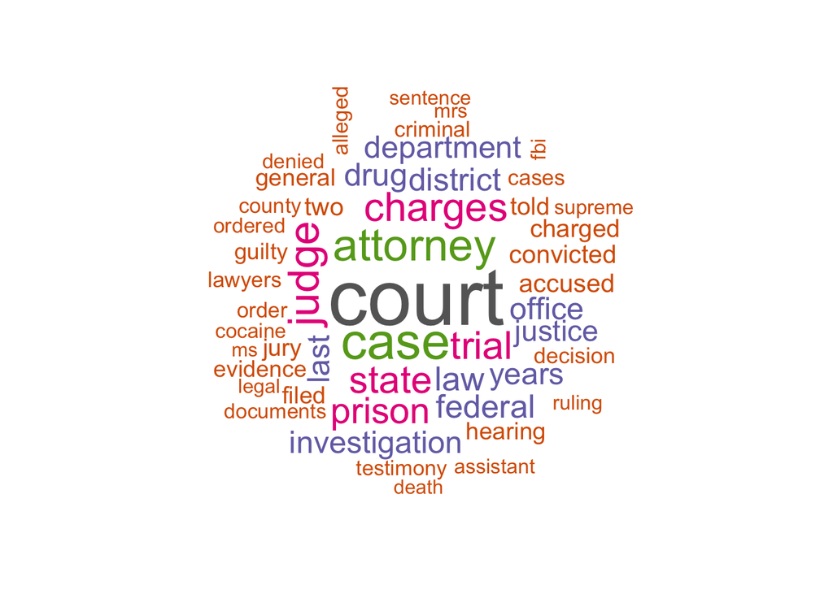

```r
#install and load packages RColorBrewer and wordcloud
library(RColorBrewer)
library(wordcloud)

# visualize topics as word cloud
# choose topic of interest by a term contained in its name
topicToViz <- grep("attorney", topicNames)[1] #search for the topic containing the word "attorney"

# select to 50 most probable terms from the topic by sorting the term-topic-probability vector in decreasing order
top50terms <- sort(tmResult$terms[topicToViz, ], decreasing = TRUE)[1:50]
words <- names(top50terms)

# extract the probabilities of each of the 50 terms
probabilities <- sort(tmResult$terms[topicToViz, ], decreasing = TRUE)[1:50]

# visualize the terms as wordcloud
mycolors <- brewer.pal(8, "Dark2")
wordcloud(words, probabilities, random.order = FALSE, color = mycolors)
```